# Climate change - análisis exploratorio

Martín Pons

2/6/2020

```r
# librerias
library(qdapRegex)
library(sentimentr)
library(syuzhet)
library(lubridate)
library(tidyverse)
library(tidytext)
library(forcats)
library(tokenizers)
library(widyr)
library(igraph)
library(ggraph)
library(topicmodels)
library(forcats)
library(scales)
library(stringr)
library(extrafont)
library(reldist)
library(grid)
library(gridExtra)
library(boot)
library(ggradar)
library(tidygraph)
library(boot)
# Sys.getenv()
Sys.setenv(JAVA_HOME = "C:\\Program Files\\Java\\jre1.8.0_251")

library(tm)
library(qdap)

# funciones auxiliares
source(here::here("scripts", "funciones_auxiliares.R"))

# paleta
plots_palette <- c("#ad5d51", "grey55", "#2b559e", "#947240")

# orden comunidades
comunidad_order <- c("GOP", "Independent", "DNC", "Progressives")
```

## Distribucion de tweets

Carga de datos. Estos datos han sido previamente procesados, sobre todo en lo que se refiere al texto de los tweets. Se excluyen términos relacionados con la pandemia que provoca la enfermedad COVID-19 (en el texto sin limpiar, hay un número amplio de términos para referirse a la enfermedad. Se han unificado todos en el término COVID19).

Se ha recogido también información sobre los seguidores de cuentas para definir 4 comunidades

- GOP: Seguidores de la cuenta del partido republicano, que no siguen la cuenta del partido demócrata ni del movimiento progresista
- DNS: Seguidores de la cuenta del partido demócrata, que no siguen la cuenta del partido republicano ni del movimiento progresista
- Progressives: Seguidores de la cuenta del movimiento progresista, que no siguen la cuenta del partido republicano ni del partido demócrata
- Independent: usuarios de tweets recogidos que no se encuentran incluidos en ninguno de los casos anteriores

```r
climate <- readRDS(here::here("datos_procesados", "formated_text_df_data", "climatechange.rds")) %>%
  filter(str_detect(text, "#?covid19|#?COVID|#?[Pp]andemic|#chinavirus|#wuhanvirus", negate = T)) %>%
  mutate(comunidad = fct_relevel(comunidad, c("GOP", "Independent", "DNC", "Progressives")))
```

```r
climate %>%
  count(comunidad) %>%
  mutate(Porcentaje = percent(n /sum(n), accuracy = 0.1))
```

```
## # A tibble: 4 x 3
##   comunidad        n Porcentaje
##   <fct>        <int> <chr>
## 1 GOP           5893 6.9%
## 2 Independent  69013 80.5%
## 3 DNC           5000 5.8%
## 4 Progressives  5838 6.8%
```

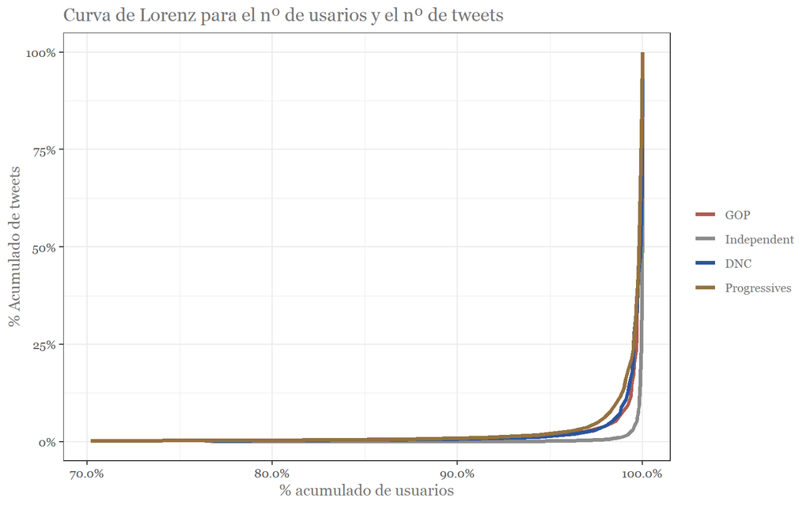

```r
# sentimiento
freq_tweets_usuario <- get_tweet_distribution(climate)

# Curva de lorenz
freq_tweets_usuario %>%
  ggplot(aes(x = porc_usuarios_acum, y = porc_tweets_acum)) +
  geom_line(aes(color = comunidad), size = 1.3) +
  scale_color_manual(values = plots_palette) +
  labs(x = "% acumulado de usuarios", y = "% Acumulado de tweets",
       title = "Curva de Lorenz para el nº de usarios y el nº de tweets") +
  scale_x_continuous(labels = scales::percent) +
  scale_y_continuous(labels = scales::percent) +
  theme_bw() +
  theme(text = element_text(family = "Georgia", color = "grey45"),
        legend.title = element_blank())
```

```r
# gini
gini_comunidades <- freq_tweets_usuario %>%
  group_by(comunidad) %>%
  summarise(gini = gini(x = tweets, weights = porc_usuarios)) %>%
  arrange(desc(gini))
```

## Analisis de Topic

### Hashtags más usados

```r
climate_unigram <- get_unigrams(climate, c("#climatechange", "#globalwarming"))
climate_hashtag <- get_hashtags(climate_unigram)
climate_frequency <- get_frequencies(climate_hashtag)

gop_hash_net <- create_hashtag_graph(climate_hashtag, "GOP", c("#climatechange", "#globalwarming"), minim_n = 3)
```

[output not shown]

```r
dnc_hash_net <- create_hashtag_graph(climate_hashtag, "DNC", c("#climatechange", "#globalwarming"), minim_n = 3)
```

[output not shown]

```r
prg_hash_net <- create_hashtag_graph(climate_hashtag, "Progressives", c("#climatechange", "#globalwarming"), minim_n = 3)
```

[output not shown]

```r
climate_graph <- bind_graphs(gop_hash_net, dnc_hash_net, prg_hash_net) %>%
  activate(nodes) %>%
  mutate(comunidad = fct_relevel(comunidad, c("GOP", "DNC", "Progressives"))) %>%
  activate(nodes) %>%
  mutate(degree = centrality_degree()) %>%
  filter(degree > 1) %>%
  activate(edges) %>%
  filter(strength > 1)
```

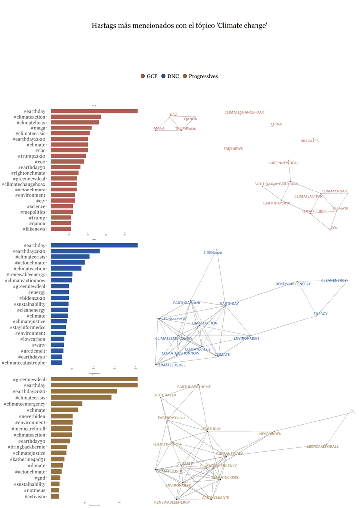

```r
grob_bars <- ggplotGrob(plot_topics(climate_frequency %>% filter(comunidad != "Independent"),
                                    c("#health"),
                                    cols = 1, colores = c(1, 3, 4)) +
                          guides(fill = F) +
                          labs(x = "Frecuencia") +
                          theme(axis.title.y = element_blank(),
                                axis.text.y = element_text(size = 16)))


set.seed(123)
grob_graph <- ggplotGrob(climate_graph %>%
  ggraph(layout = "nicely") +
  geom_edge_link(alpha = 0.5) +
  geom_node_point(alpha = 0.3) +
  geom_node_text(aes(label = nodes, color = comunidad), size = 4.8, family = "Candara", repel = T) +
  facet_nodes(~comunidad, ncol = 1, scales = "free") +
  theme_bw() +
  guides(color = F) +
  scale_color_manual(values = plots_palette[c(1, 3, 4)]) +
    theme(panel.grid = element_blank(),
          strip.background = element_blank(),
          strip.text = element_text(family = "Georgia", size = 11, color = "white"),
          panel.border = element_blank(),
          axis.title = element_blank(),
          axis.text = element_blank(),
          axis.ticks = element_blank()))


titulo <-  textGrob(label = "Hastags más mencionados con el tópico 'Climate change'", gp = gpar(fontfamily = "Georgia", cex = 2))
leyenda <- legendGrob(labels = c("GOP",  "DNC", "Progressives"),  pch = 21,
                      gp = gpar(fill = plots_palette[c(1, 3, 4)], fontfamily = "Georgia", cex = 1.5), nrow = 1)

plots_grob = arrangeGrob(grob_bars, grob_graph, nrow = 1, widths = c(4, 6))

grid.arrange(titulo, leyenda, plots_grob, heights = c(1, 1, 8))
```

```r
# plot_topics(healthcare_frequency, c("#covid19", "#health"))
```

### Temas propios de comunidades

#### Hashtags

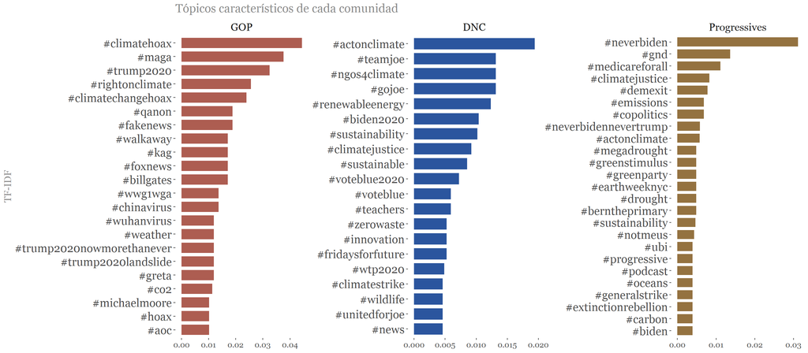

```r
climate_tfidf_hashtags <- get_tfidf(climate_frequency %>% filter(comunidad!= "Independent"))

plot_tfidf(climate_tfidf_hashtags, cols = 3, colores = c(1, 3, 4)) +
  labs(title = "Tópicos característicos de cada comunidad", y = "TF-IDF") +
  guides(fill = F) +
  theme(axis.title.x= element_blank(),
        axis.text.y = element_text(size = 16),
        legend.title = element_blank(),
        strip.text = element_text(size = 15))
```

#### Menciones

La referencia distintiva de cabecera para el GOP es BribeBart News. Un medio conservador, que tuvo como director a Steve Bannon.

La mención más destacada en el partido demócrata es (Rick Wilson)[http://www.therickwilson.com/about/] , estratega político asociado al (Lincoln Project)[https://lincolnproject.us/], un movimiento republicano anti Donald Trump

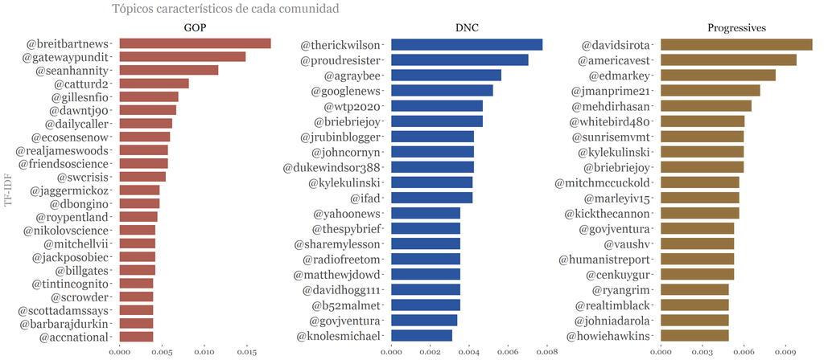

```r
climate_tfidf_mentions <- get_tfidf(climate_unigram %>% filter(str_detect(word, "^@"),comunidad!= "Independent") %>% get_frequencies())

plot_tfidf(climate_tfidf_mentions, cols = 3, colores = c(1, 3, 4)) +
  labs(title = "Tópicos característicos de cada comunidad", y = "TF-IDF") +
  guides(fill = F) +
  theme(axis.title.x= element_blank(),
        axis.text.y = element_text(size = 16),
        legend.title = element_blank(),
        strip.text = element_text(size = 15))
```

#### Sentimiento - NRC

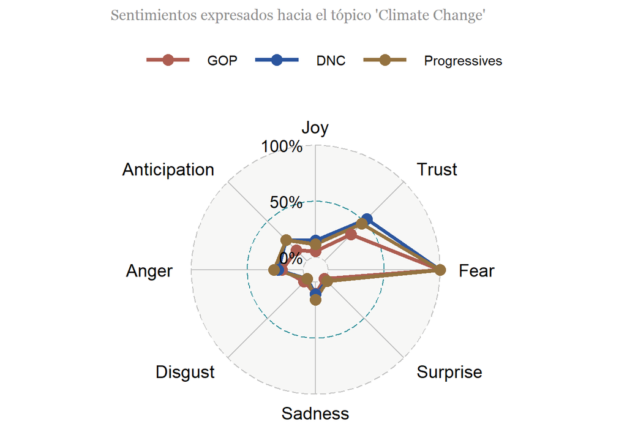

```r
# climatechangte
nrc_climate <- climate_unigram %>%
  filter(comunidad!= "Independent") %>%
  inner_join(get_sentiments("nrc"), by = "word") %>%
  filter(!sentiment %in% c("positive", "negative")) %>%
  count(comunidad, sentiment, sort = T) %>%
  mutate(sentiment = str_to_title(sentiment)) %>%
  ungroup() %>%
  group_by(comunidad) %>%
  mutate(n = rescale(n)) %>%
  pivot_wider(names_from = sentiment, values_from = n) %>%
  select(comunidad, Joy, Trust, Fear, Surprise, Sadness, Disgust, Anger, Anticipation, Joy)

# predomina miedo
ggradar(nrc_climate %>% ungroup() %>% mutate(comunidad = fct_drop(comunidad)), group.colours = plots_palette[c(1, 3, 4)], legend.position = "top",
        group.point.size = 4,
        plot.title = "Sentimientos expresados hacia el tópico 'Climate Change'", legend.text.size = 11) +
  theme(plot.title = element_text(size = 12, family = "Georgia", color = "grey55"),
        axis.title = element_text(family = "Georgia"))
```

### Analisis green new deal

#### sentimiento - Polaridad

Sorporendentemente los tres grupos dan una valoración positiva.

```r
# he filtrado fuera temas algunos temas políticos porque hay demasiada ironía
green_sent <- readRDS(here::here("datos_procesados", "formated_sent_df_data", "greennewdeal_sent.rds")) %>%
  filter(str_detect(text, "#?covid19|#?COVID|#?[Pp]andemic|#chinavirus|#wuhamvirus", negate = T))

green_sent %>%
  filter(!is_retweet) %>%
  group_by(comunidad) %>%
  summarise(sent = mean(ave_sentiment),
            n = n())
```

```
## # A tibble: 3 x 3
##   comunidad     sent     n
##   <chr>        <dbl> <int>
## 1 DNC          0.227   251
## 2 GOP          0.187   841
## 3 Progressives 0.253  1276
```

En este caso, en el partido republicano hay un número significativo de tweets irónicos, con lo que este tipo de análisis queda invalidado

```r
green_sent %>%
  filter(status_id == "1260399668594454531") %>% .$text
```

```
## [1] "@rooticusprime @sadieisrael @gatewaypundit only leftist approved thought i am sure we will learn to love our green new deal and spout that aoc is a genius project dragonfly was for us not china"
```

# Correlación de términos

Esto es parecido al grafico de red al lado de las barras, pero ahor midiendo directamente la correlación entre los hashtags con el coeficiente phi. puede que sustituya al grafico de red de arriba.

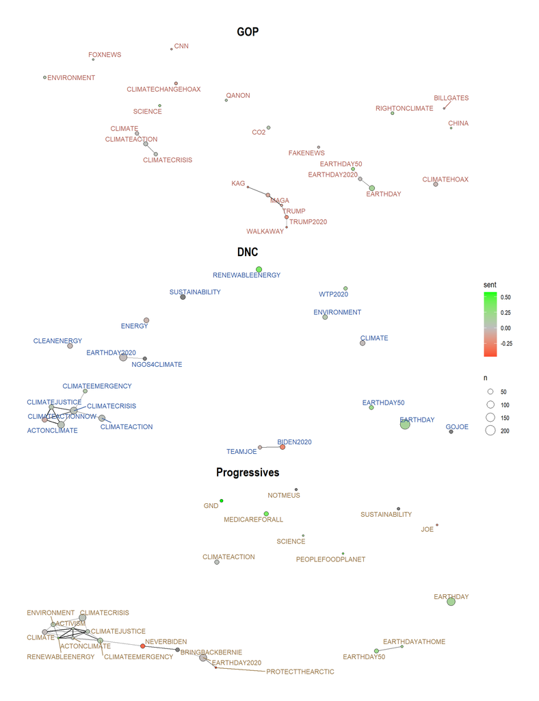

```r
gop_cor_net <- get_correlation_network(climate_hashtag, climate_frequency, com = "GOP", exclude_words = "#greennewdeal", cor_limit = 0.2) %>%
  activate(nodes) %>% mutate(comunidad = "GOP")
dnc_cor_net <- get_correlation_network(climate_hashtag, climate_frequency, com = "DNC", exclude_words = "#greennewdeal", cor_limit = 0.2) %>%
  activate(nodes) %>% mutate(comunidad = "DNC")
prg_cor_net <- get_correlation_network(climate_hashtag, climate_frequency, com = "Progressives", exclude_words = "#greennewdeal", cor_limit = 0.2) %>%
  activate(nodes) %>% mutate(comunidad = "Progressives")

climate_net <- bind_graphs(gop_cor_net, dnc_cor_net, prg_cor_net) %>%
  activate(nodes) %>%
  mutate(comunidad = fct_relevel(comunidad, c("GOP", "DNC", "Progressives")))

climate_net %>%
  ggraph(layout = "fr") +
  geom_edge_link(aes(edge_alpha = correlation), show.legend = FALSE) +
  geom_node_point(pch = 21, aes(fill = sent, size = n)) +
  geom_node_text( aes(label = name, color = comunidad), repel = TRUE, size = 3) +
  facet_nodes(~comunidad, ncol = 1, scales = "free") +
  scale_fill_gradient2(low = "red", high = "green", mid = "grey") +
  scale_color_manual(values = plots_palette[c(1, 3, 4)]) +
  facet_nodes(~comunidad, ncol = 1, scales = "free") +
  theme_graph() +
  guides(color = F) +
  theme(strip.text = element_text(size = 16))
```

```r
# gop_cor_net <- ggplotGrob(plot_correlation_network(climate_hashtag, climate_frequency, com = "GOP", exclude_words = "#greennewdeal",
#                                                    text_size = 2, point_size = 2, text_color = plots_palette[1]))
# dnc_cor_net <- ggplotGrob(plot_correlation_network(climate_hashtag, climate_frequency, com = "DNC", exclude_words = "#greennewdeal",
#                                                    text_size = 2, point_size = 2, text_color = plots_palette[3]))
# prg_cor_net <- ggplotGrob(plot_correlation_network(climate_hashtag, climate_frequency, com = "Progressives", exclude_words = "#greennewdeal",
#                                                    text_size = 2, point_size = 2, text_color = plots_palette[4]))

# grid.arrange(gop_cor_net, dnc_cor_net, prg_cor_net, ncol = 1)
```

### Polaridad

Niveles inexistentes de polarización al comparar las comunidades

```r
library(boot)

pol_test_dif <- readRDS(here::here("datos_procesados", "formated_polarization_df_data", "polarization_testing", "climatechange_polarization.rds"))


pol_test_dif[-1]
```

```
## $IC
##               2.5%      97.5%
## DNC-GOP 0.02083333 0.07886905
## DNC-PRG 0.02083333 0.07916667
##
## $resultado
## [1] "No se encuentran diferencias en medias"
```

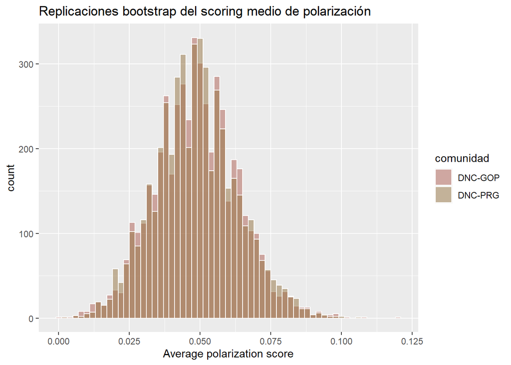

```r
pol_test_dif$data %>%
  ggplot(aes(x = sentimiento)) +
  geom_histogram(aes(group = comunidad, fill = comunidad), color = "white", alpha = 0.5, binwidth = 0.002, position = "identity") +
  scale_fill_manual(values = plots_palette[c(1, 4)]) +
  labs(x = "Average polarization score", title = "Replicaciones bootstrap del scoring medio de polarización")
```